# Lab: Pricing optimization

Jimmy Azar

## Introduction

In this lab, we will explore optimal pricing based on demand curve estimation. We are provided information on the willingness-to-pay (wtp) amounts of consumers for a given product. Willingness-to-pay is the maximum amount a consumer is willing to pay for purchasing a given product.

In this lab, you will experiment with fitting a distribution on wtp data, and then you will derive the demand curve and find the optimal price to set for the product so as to maximize profitability.

## Explore the data

The data on wtp is provided in a text file named “wtp.txt”. Read in the data and inspect the values; use `summary()` to view the range and other useful statistics. Based on this data, how many customers were surveyed?

```
data <- read.table("wtp.txt", header=TRUE)
```

## Fit a normal distribution

### Method of moments

We may fit a normal distribution using the method of moments by setting the theoretical moments (mean and standard deviation) to the sample moments derived from the data. Thus, to fit a normal distribution over the 1D data, we need to compute the sample mean and standard deviation (hint: `mean()` and `sd()`). Next, plot the theoretical normal density function over the range of values that wtp takes (hint: `min()` and `max()`) using the function `dnorm()`. Once the plot is generated, add the actual densities obtained using the histogram as you’ve done before (hint: `hist(..., add=TRUE)`).

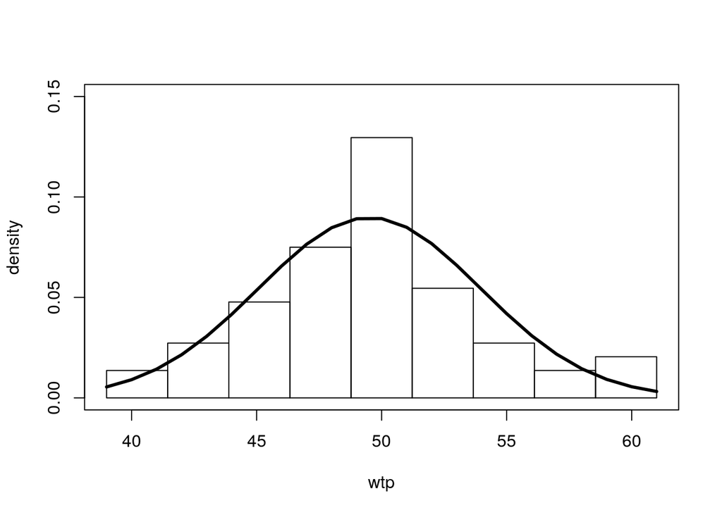

### Method of maximum-likelihood

We may instead fit a normal distribution using the method of maximum likelihood. To obtain the maximum likelihood estimates of the mean and standard deviation you may use the function `fitdist()` (package: “fitdistrplus”). Set the second argument to “norm” to specify fitting a normal distribution.

```
fitn <- fitdist(data$wtp,"norm")
summary(fitn)
```

Inspect the summary returned; what are the maximum likelihood estimates of the mean and standard deviation?

Plot the theoretical normal density function over the range of values that wtp takes using the function `dnorm()` but now with the maximum likelihood estimates which may be obtained from `fitn$estimate`. As before, superimpose the actual densities obtained using a histogram plot.

Note that for a normal distribution, the maximum likelihood (ML) estimates can be theoretically derived (whithout the need for `fitdist()`): the ML estimate of the mean will be the same as the sample mean, whereas the ML estimate of variance would be $\sum_i (X_i-\overline{X})^2/n$, where $n$ is the number of samples. The sample (unbiased) variance uses $n-1$ instead in the denominator. Therefore, for a normal distribution, the ML estimate of standard deviation can be obtained from the sample standard deviation (computed in the previous section) by multiplying by $\sqrt{(n-1)/n}$ (try it).

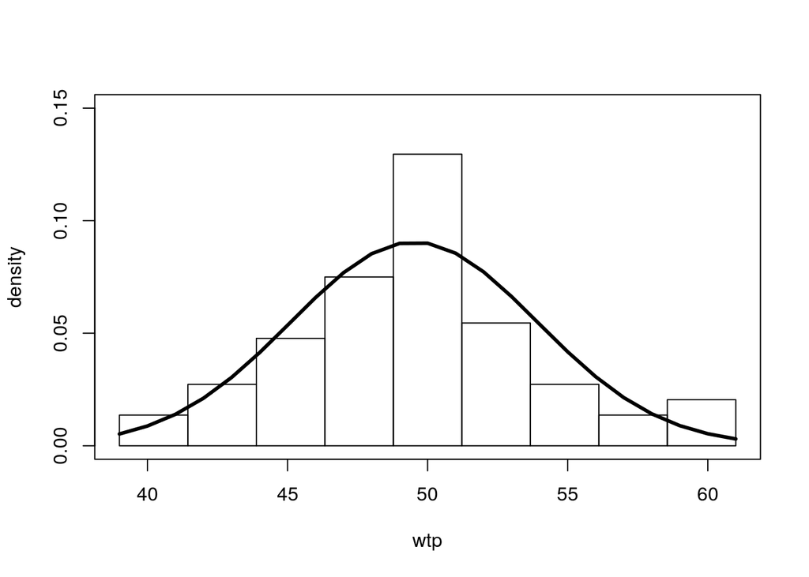

## Fit a logistic distribution

We may also fit a logistic distribution (pdf) instead of a normal distribution. Note: the logistic **function** which has a sigmoid shape is the cumulative distribution function (cdf) of the logistic probability **distribution** function (pdf). We also explore both the method of moments and maximum likehood for fitting the model.

### Method of moments

We may fit a logistic distribution using the method of moments by setting the theoretical parameters “location” (or mean) and “scale” to the sample location and scale derived from the data. Compute these latter from the definitions of these parameters as shown below (hint: `?dlogis` to view the equations) :

```
m <- mean(data$wtp)             #location parameter
s <- sqrt(var(data$wtp)*3/pi^2) #scale param: s
```

Next, plot the theoretical logistic probability density function over the range of values that wtp takes using the function `dlogis()`. Add the actual densities obtained using a histogram plot. How does the fit appear?

### Method of maximum-likelihood

We may instead use the method of maximum likelihood using the function `fitdist()`. Set the second argument to “logis” to specify fitting a logistic distribution.

```
fitlog <- fitdist(data$wtp,"logis")
summary(fitlog)
```

Inspect the summary returned; what are the maximum likelihood estimates of the parameters?

Plot the theoretical logistic density function over the range of values that wtp takes using the function `dlogis()` but now with the maximum likelihood estimates instead. Superimpose the actual densities obtained using a histogram plot.

You may have noticed that both the normal and logistic distributions fit very well over the wtp data. We will adopt the logistic distribution from here on and proceed to estimate the demand curve.

## Demand curve estimation

Given the fitted wtp logistic distribution (by whichever method), for a given price $p$, the demand corresponds to the area to the right tail of the distribution, i.e. $P(wtp \geq p)$ which is equal to $1-P(wtp<p) = 1-\text{cdf}(p)$. Strictly speaking, demand (as a count) is equal to this area multiplied by the market size. Thus, write a function `demand()` which takes as input a certain price $p$, in addition to logistic distribution parameters $m$ and $s$ as well as “market_size”, and returns the demand level at price $p$. Note that to compute the area $P(wtp \leq p)$ you may use `plogis()`.

```
demand <- function(p,m,s,market_size){
  ...
}
```

Set the market size to 10,000 and plot the demand curve as a function of price for the range of prices given in the wtp data.

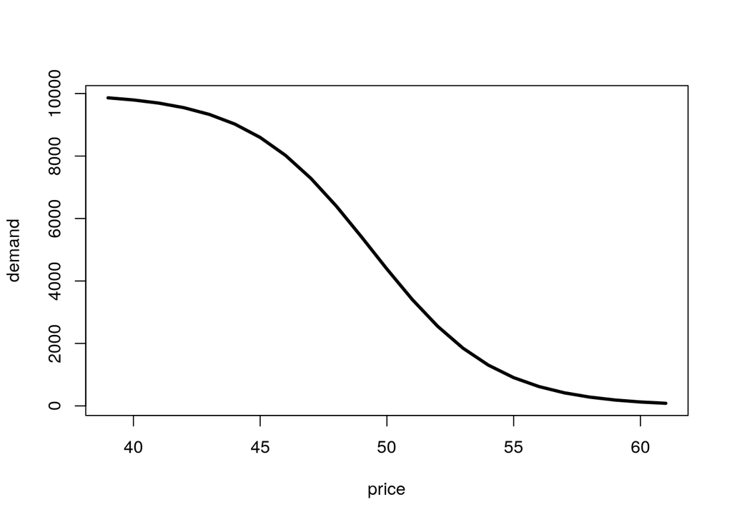

## Price optimization

At a given price $p$, the profit is simply the demand at $p$ multiplied by ($price-cost$). Write a function `profit()` that takes as input the price $p$, the cost of a product unit, the parameters $m$ and $s$ of a logistic distribution, and the market size. The function should return the evaluated profit.

```
profit <- function(price, cost, m, s, market_size){
  ...
}
```

Use your function to evaluate the profit at a price of $30, a cost of $15, and a market size of 10,000 consumers. Repeat the same but for a price of $20, and then $18. In what follows, we assume the cost of a product unit is $15 and the market size is 10,000.

We will use an optimization routine to find the optimal price which maximizes profit. To this end, call the function `optim()` and provide it with an initial price value of say $20, a function to maximize (i.e. `profit`), the known input parameters of that function; also, specify the optimization method as “BFGS”, and set the control argument to `control=list(fnscale=-1)` to indicate that a maximization of the function `profit` is required (as opposed to minimization by default).

```
#optimal price to maximize profit
obj <- optim(20, profit, cost=15, m=m, s=s, market_size=10000,
             method="BFGS", control=list(fnscale=-1)) #set initial price > cost=15
```

What is the optimal price found? And what is the corresponding maximum profit?

```
price_opt <- obj$par
profit_opt <- (obj$value)
```

Finally, plot the profit as a function of price for a selected range of values in order to visually validate the results.